# Microplastics in Lettuce: The Impacts of Packaging on Dietary Microplastic Exposure Through Produce

Susannah Budd

05/04/2019

### Abstract

Microplastic contamination is a pressing issue, and one of particular concern for the spheres of ecosystem and human health. Dietary microplastic contamination has been of significant concern recently as a potential pathway for bioaccumulation of microplastics in humans. However, this body of literature has focused largely on the risk of contamination through seafood, as microplastic contamination in the ocean is particularly high. This research aimed to investigate microplastic levels in romaine lettuce intended for human consumption and investigate the role of plastic packaging in potential microplastic contamination in order to gain a new perspective on dietary exposure routes. In comparing packaged and unpackaged lettuce, the null hypothesis of “there is no difference in microplastic quantities in romaine lettuce with or without plastic packaging” could not be rejected (p-value = 0.5839). This reality brings up further questions concerning the extent of laboratory microplastic contamination and the future of research into microplastics and produce.

### Introduction

Microplastics, small fragments of plastics often undetectable to the naked eye, have become a consistent component of the environment of the entire biosphere. Plastics and their additives have been located throughout every major body of water and in many species, including humans (GESAMP 2016). The ubiquity of microplastics is of particular concern as many plastic additives, such as BPA, have been shown to be harmful to human health (Calafat et al. 2008), which has lead to a growing concern around dietary microplastic exposure. One particular area of consumption which has not had significant scientific investigation is that of produce. This study attempts to diversify the body of literature surrounding dietary microplastics by investigating romaine lettuce, a previously unresearched food item, and the impact which plastic packaging may have on its observed microplastic levels.

To date, there has been no significant scientific investigation into produce. Due to the density of microplastics in the ocean, investigation into microplastic proliferation has largely centered around oceanic products, such as seafood (Karbalaei et al. 2018). Additionally, many of these studies focus on these products well before they are intended for human consumption, including areas which usually aren’t consumed by humans, such as the gastrointestinal tract (Baalkhuyur et al. 2018, Rochman et al. 2015, Karlsson et al. 2017). Much of the significant research conducted on non-marine dietary microplastics was conducted on beverages and solubles, including honey, salt, and beer (Karami et al. 2017, Iñiguez et al., Liebezeit and Liebezeit 2013, 2014). While microplastics were found in all of these, contamination was not avoided in any of them (Lachenmeier et al. 2015). By investigating an under-researched product, produce, at the stage of production nearest to consumption (in the grocery store), this research aims to begin to create a more robust understanding of how all foodways impact human microplastic exposure, and how processing tactics, such as packaging, play a role in exposure.

One particular area of consumption which has not had significant scientific investigation is that of produce. Due to the density of microplastics in the ocean, investigation into microplastic proliferation has largely centered around oceanic products, such as seafood (Karbalaei et al. 2018). Additionally, many of these studies focus on these products well before they are intended for human consumption, including areas which usually aren’t consumed by humans, such as the gastrointestinal tract (Baalkhuyur et al. 2018, Rochman et al. 2015, Karlsson et al. 2017). Because of this, there is no scientific consensus regarding how significant dietary ingestion of microplastics is to overall microplastic exposure. By investigating produce at the stage of production nearest to consumption (in the grocery store), this research aims to begin to create a more robust understanding of how all foodways impact human microplastic exposure, and how processing tactics, such as packaging, play a role in exposure.

In order to begin to investigate these aims, the questions to investigate must first be developed. For the purpose of this particular research, the overarching questions are: Are there detectable microplastics in romaine lettuce intended for human consumption? If yes, do microplastic concentrations vary depending on whether or not they were packaged in plastics? Because of romaine’s availability both in unpackaged heads and prepared plastic bags, it serves as the ideal produce through which to investigate how the phenomenon of how packaging impacts microplastic exposure and subsequent leaching. Furthermore, this research will be conducted using a hypothesis test, where a null hypothesis will be rejected or not rejected based on whether a p-value of < 0.05 is obtained. For the purpose of this research, the null hypothesis is “there is no difference in microplastic quantities in romaine lettuce with or without plastic packaging.” This metric will be used to compare romaine lettuce heads with and without plastic packaging, and assess the impact which plastic packaging may have on microplastic exposure.

### Methods

1. **Two unpackaged heads of romaine lettuce** and **two heads of romaine lettuce in plastic packaging** (pre-chopped for salad is acceptable) were purchased from 5 nearby stores - Sprouts on Foothill Boulevard, Stater Bros. on N. Garey Avenue, Cardenas on E. Holt Avenue, El Super on E. Holt Avenue, and Super King on Auto Center Drive. Upon purchasing the lettuce, it was carried out **individual paper bags** to avoid contamination, which were sealed to avoid contamination with airborne particulates, however, some contamination was likely unavoidable.
2. In the lab, a **glass blender** was obtained. Unbagged lettuce was thoroughly washed with deionized water, and then the blender was filled with leaves until they reached the top. Bagged lettuce leaves were inserted into blender until they reached the top without washing, as the lettuce was labeled pre-washed.
3. **200 mL of Milli-Q deionized water** were added to the blender. The solution was blended for 30 seconds on the slower “grind” setting, and then for 60 seconds on the faster “cream” setting.
4. The contents of each beaker were strained through a **stainless steel filter with a mesh size of 5 mm** to capture larger organic fibers while allowing all particles meeting the qualification of “microplastic” (>5mm) to pass through until 100 mL of solution was obtained. This solution was placed in a glass beaker covered with **aluminum foil** to avoid airborne contamination.
5. 5 mL of the blended lettuce solution was extracted using a **glass pipette** and placed in a **100 mL glass beaker**. Due to the large quantities of cellulose in lettuce, the enzyme cellulase from Niger Aspergillus niger was used to digest the remaining organic material while leaving any microplastic particles intact. **5 mL of cellulase** and **10 mL of a phosphate-buffered saline** (PBS) solution (1 L prepared with **8 g sodium chloride**, **200 mg potassium chloride**, **1.44 g disodium phosphate** and **240 mg monopotassium phosphate** in **deionized water**, set to pH 5.0 using hydrochloric acid) were added. The beaker was covered with **aluminum foil**.
6. The solution was incubated at 50° C for 4 days.
7. Steps 2-6 were repeated for every purchased head of lettuce.
8. **NaCl in solution with deionized water** (density=1.2g/mL, stirred for 10 minutes) was added to the incubated solution until the beaker had 100 mL of solution in it. The solution was left to settle for 30 minutes, then a **vacuum system** was used to collect the top 40 mL of each sample and any floating microplastics within it.
9. **5 mL of 0.08 g/mL Nile red dye solution** was added to this extracted solution and allowed to stain for 30 minutes.
10. This extracted and stained solution was run through **vacuum filtration with an entirely glass apparatus** to separate stained fibers from their liquid matrix. The resulting filter paper was placed in a **glass beaker**, covered with **aluminium foil**, and allowed to dry overnight.
11. **RStudio** was used to generate random coordinate points. A grid was created on the dried filter paper, and four random points were plotted onto this grid on each paper.
12. The **digital Revolve microscope with fluorescent light** (4x zoom lens, TXRED fluorescent/FL overlay at 100% brightness, ~110 ms capture) and ocular techniques were used to count the number of fluorescent particles present at each marked location on the paper.
13. Steps 8-12 were repeated with each incubated solution.
14. In order to mitigate the impacts of contamination or procedural error, the results were corroborated through the use of **blanks**. 3 water “samples” went through steps 2-11 alongside the experimental samples, but with 100 mL of deionized water rather than solution material. All equipment used was washed thoroughly before and after touching any sample, and all water used to wash was deionized so as to avoid contamination from the water.
15. The methods of Löder et al. 2017, Maes et al. 2017, Wang and Wang 2018, Karlsson et al. 2017, and Quinn et al. 2018 were consulted in developing these proposed procedures.

### Results

The data collection yielded five replicates and five pseudo-replicates for both bagged and unbagged lettuce, as two bagged and unbagged heads were purchased at five different stores. In order to more accurately reflect these replicates, the number of microplastics found on each head of lettuce was averaged with its pair. For example, the number of microplastics found on each bagged lettuce head purchased at Cardenas were averaged with one another. The graph below shows the box plots of these averages for bagged and unbagged lettuce.

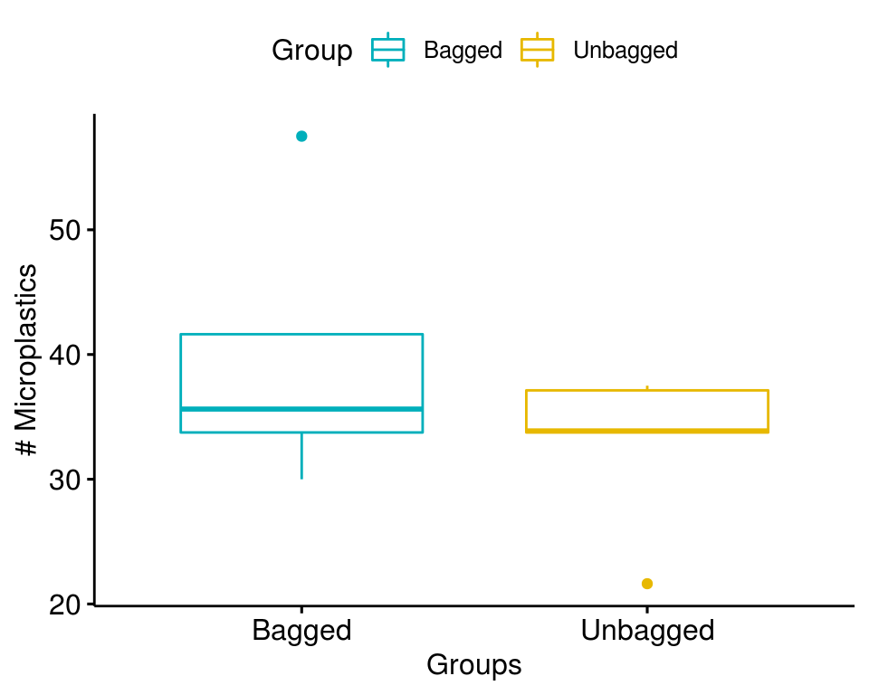

#### Normality Tests

This experiment was designed to test the null hypothesis of “there is no difference in microplastic quantities in romaine lettuce with or without plastic packaging.” In order to determine whether or not to reject the null hypothesis, whether or not the data fell within normal distribution was first assessed, using Q-Q Plots and the Shapiro-Wilk normality test.

##### Bagged

For bagged lettuce data, the Shapiro-Wilk normality test yielded a p-value of 0.2768, indicating that it is within the bounds of normal distribution. The Q-Q plot, shown below, also demonstrates that most points fall within the expected bounds.

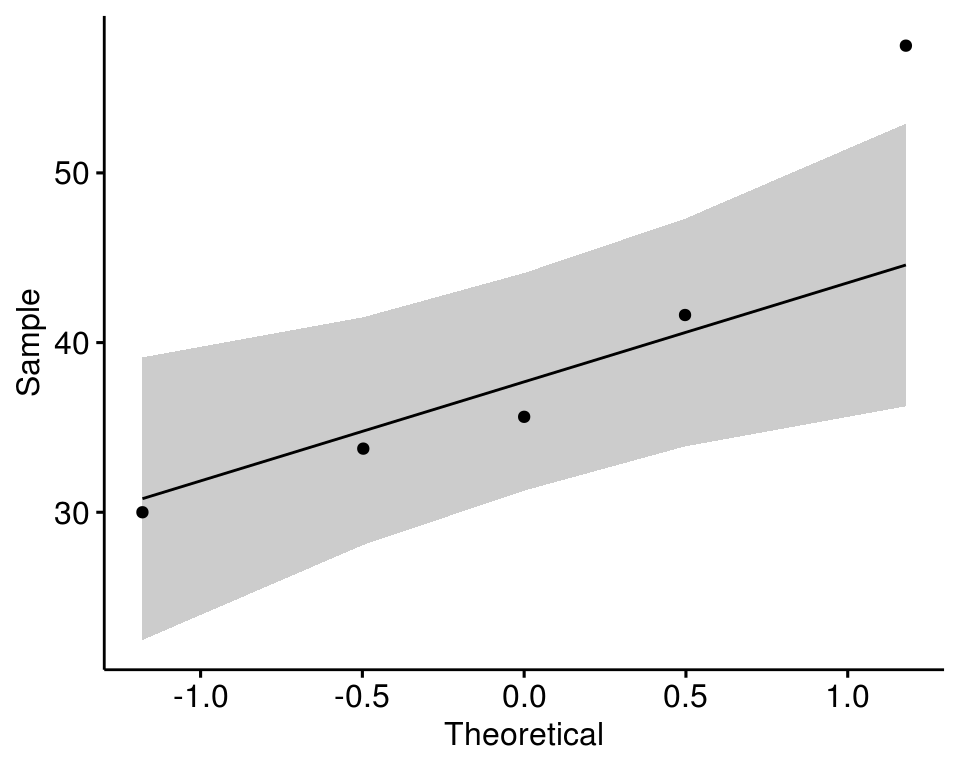

##### Unbagged

For unbagged lettuce data, the Shapiro-Wilk normality test yielded a p-value of 0.04526, indicating that it is not within the bounds of normal distribution. The Q-Q plot, shown below, also demonstrates that, while most points fall within the expected bounds, some are much further out of normal distribution than they were for the bagged lettuce data.

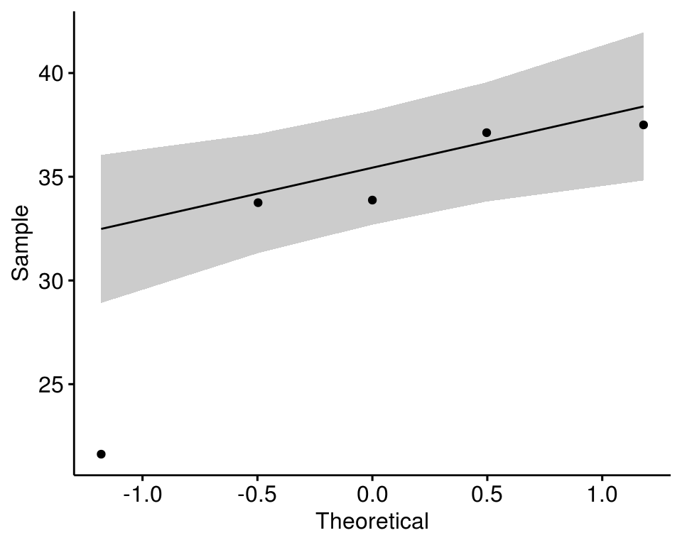

#### Statistical Analysis

As the unbagged data fell outside of normal distribution, a Paired Samples Wilcoxon Test was used to evaluate the data. Using this test, a p-value of 0.5839 was yielded. This p-value does not demonstrate statistical significance, meaning that the null hypothesis may not be rejected. A Two-Sample T-Test was also conducted, yielding a p-value of 0.2538. This also does not demonstrate statistical significance, indicating that statistical significance likely would not be demonstrated even if the data fell within normal distribution.

### Discussion

Although statistical significance was unable to be determined, the raw numbers of microplastic particles observed in the samples indicates that further research into the presence of microplastics in produce is warranted. At least 5, and up to 103, microplastics were observed at each point on each piece of filter paper which was analyzed. The filter papers were generated from just 5 mL of “lettuce slurry,” and the points observed on the filter papers were just 400 μm across. This indicates that they typical number of microplastics consumed when eating a salad, for example, would likely be much higher than the numbers observed in this experiment. Additionally, the numbers which were observed in this experiment were not dissimilar from those found in other, similar studies - even those involving notoriously contaminated seafood. For instance, De Witte et al. found between 4.3 and 6.1 plastic fibers per 10 grams of mussel material in a study conducted in 2014 on bivalves intended for public consumption. The relatively high numbers found in this study indicate that microplastics in produce may be an issue of significant concern which should be investigated further.

That being said, there was a significant risk of contamination in this experiment. Three blanks were used to evaluate laboratory microplastic contamination, Although the average of the three blanks was lower than averages found for all but three of the experimental samples, most of these differences were quite small. As was noted by Lachenmeier et al. (2015), methodologies for finding microplastics have consistently struggled to avoid contamination, as air and water oftentimes contains microplastic particles. Although great care was taken to ensure that samples were covered at all times, and only deionized Milli-Q water was used in association with this experiment, laboratory contamination was not avoided in this experiment either. It is possible that the deionized water had some remaining microplastics in it, particularly as the Milli-Q apparatus is made out of plastic. Although water is a very necessary element of experiments such as these, future experiments may consider testing the deionized water itself for microplastics before conducting the experiment, or further purifying the water by running it through the glass vacuum apparatus used in the experiment, so that any particles in the water large enough to be captured by the filter would be suspended before the water was used in the experiment. Another major contamination concern is airborne contamination; however, airborne contamination is much more difficult to avoid. This being said, some further precautions may be taken. A reduction of the plastics present in the lab prior to the conduction of this experiment, an investment in cotton lab coats and gloves (polyester and latex were used to complete this experiment), and perhaps the completion of the entire experiment under a fume hood may help to reduce airborne microplastic contamination. Additionally, as airborne contamination is a large concern, testing the air in the laboratory for microplastics may help to provide some context as to where the contamination is coming from, and perhaps indicate more concretely how that contamination may be minimized.

Additionally, some methodological issues may have contributed to potential error in the data obtained. One particular issue which was encountered was that, in an attempt to liquefy the lettuce in as little time as possible, the original solution was strained using a metal sieve. Although this allowed the liquids to be separated from remaining solids, the fibrous remains largely accumulated on top of the sieve and did not filter into the solution used to produce the papers which were observed. This may have lead to the underestimation of how many observed plastics were in the lettuce, as many particles may have become trapped in this pile and not made it into the experimental solution. Another issue which was encountered was the difficulty to determine which particles viewed under the microscope were synthetic, and which were simply undigested lettuce fibers. A misinterpretation of remaining biotic material may have lead to an overestimation of the microplastics present in the samples. One way which both of these issues could be resolved is through a more thorough enzyme digestion, similar to the one described by Löder et al. (2017).When taking the time to do a complete enzyme digestion, the blended lettuce would not have to be strained, as the approximately three week-long process would thoroughly break down the biomatter on its own. Additionally, the longer digestion process would make it less likely that biotic fibers would remain in the solution and perhaps be mistaken as microplastic particles. If the time constraint is too significant to complete a full digestion process, a combination of boiling and nitric acid could also be used to eliminate biotic material, as per the methods of Rochman et al. (2015), albeit risking potential damage to and subsequent underestimation of microplastics in the material.

One additional improvement which may be made to similar research in the future may be found in the number of replicates used. The statistical power of this particular experiment with 10 replicates per group was found to be 0.41, indicating that the probability of making a Type II error and mistakenly not rejecting a null hypothesis which should be rejected is greater than 50%. In this experiment, it was found that in order to obtain statistical power of 0.8, 26 samples from each group would be needed, for a total of 52 experimental samples, plus blanks. On the box plot, there appears to be a slight trend towards more microplastics being present on bagged rather than unbagged lettuce, however, with the number of replicates which were used in this research, that trend is not statistically significant. As statistical significance was not obtained, the null hypothesis of “there is no difference in microplastic quantities in romaine lettuce with or without plastic packaging” could not be rejected, and the role of packaging in microplastic quantities in produce could not be affirmatively determined. In order to determine whether or not packaging does or does not play a role in microplastic quantities on romaine lettuce, this or a similar experiment would likely have to be repeated with many more replicates.

Due to the magnitude of work necessary to reproduce these results with more replicates and more thorough enzymatic digestion, this particular experiment likely should not be repeated without a much longer time frame available for its completion. If this experiment could be re-conducted over the course of at least two months, or even a semester, then it would be interesting to investigate whether or improving the enzymatic digestion and increasing the number of replicates produced statistical significance. In lieu of such a time commitment, the inconclusive results of this experiment may still serve as a starting point for further research into the presence of microplastics in produce. As this experiment observed microplastic quantities similar to those observed in other, more researched dietary arenas, further research into whether or not these values are of concern, or likely due to contamination, are warranted. Experiments comparing microplastics found on various produce with background levels found in laboratory air or water samples may be useful in concluding whether or not microplastics in produce are a genuine concern. Additionally, further research investigating the impacts of plastic packaging and airborne contamination individually may be more illuminating than a study comparing the two, as levels of microplastics in both scenarios are likely high. Although the high microplastic levels observed may be due to contamination, further research is necessary to affirmatively answer this question.

### Conclusion

As statistical significance was not obtained in this experiment, it is difficult to speak conclusively as to what may be learned from this research. In many ways, this experiment simply provides a foundation on which more targeted questions may be built. However, the relatively high levels of microplastics found in this experiment indicate that produce microplastic exposure may be comparable to areas more traditionally considered to be high-risk, such as seafood. This reality underscores the necessity, discussed by Rist et al. (2018), of expanding and contextualizing the debate around microplastics. Microplastics have become entirely omnipresent across essentially all global environments, so much so that no laboratory protocol has been designed which may entirely eliminate the risk of microplastic contamination. While it is of course important to understand the risks posed by a threat as universal as microplastic exposure, dietary pathways are still just one of many routes through which individuals are exposed to microplastic pollution every day. While this indication that microplastics may be present in produce as well as other more traditionally high-risk foods is certainly unnerving, it remains just one piece in a large web of constant microplastic exposure. The microplastics observed in lettuce samples, as well as the high risk of laboratory contamination, indicates how universal microplastics are in almost all environments today. As this report indicates, areas which were previously considered to be unlikely sources of microplastic exposure may be found to have substantial contamination, underscoring the need for further research into the scope of microplastic exposure.

### Bibliography

Baalkhuyur F, Bin Dohaish E, Elhalwagy M, Alikunhi N, AlSuwailem A, Røstad A, Coker D, Berumen M, Duarte C. 2018. Microplastic in the gastrointestinal tract of ﬁshes along the Saudi Arabian Red Sea coast. Marine Pollution Bulletin. 107(A):407-415.

Batel A, Linti F, Scherer M, Erdinger L, Braunbeck T. 2016. Transfer Of Benzo[a]Pyrene From Microplastics To Artemia Nauplii And Further To Zebrafish Via A Trophic Food Web Experiment: Cyp1a Induction And Visual Tracking Of Persistent Organic Pollutants. Environmental Toxicology and Chemistry. 35(7):1656-1666.

Calafat A, Ye X, Wong L, Reidy J, Needham L. 2008. Exposure of the U.S. Population to Bisphenol A and 4-tertiary-Octylphenol: 2003–2004. Environmental Health Perspectives. 116(1):39-44.

Fossi M, Marsili L, Baini M, Giannetti M, Coppola D, Guerranti C, Caliani I, Minutoli R, Lauriano G, Finoia M, Rubegni F, Panigada S, Berub M, Ramírez J, Panti C. 2016. Fin whales and microplastics: The Mediterranean Sea and the Sea of Cortez scenarios. Environmental Pollution. 209:68-78.

[GESAMP] Joint Group of Experts on the Scientific Aspects of Marine Environmental Protection. 2016. Sources, Fate And Effects Of Microplastics In The Marine Environment: Part Two Of A Global Assessment. GESAMP. 93:1-220.

Iñiguez M, Conesa J, Fullana A. 2017. Microplastics in Spanish Table Salt. Scientific Reports. 7:8620.

Karami A, Golieskardi A, Choo C, Larat V, Galloway T, Salamatinia B. 2017. The presence of microplastics in commercial salts from different countries. 7:46173.

Karbalaei S, Hanachi P, Walker T, Cole M. 2018. Occurrence, sources, human health impacts and mitigation of microplastic pollution. Environmental Science and Pollution Research. 25:36046-36063.

Karlsson T, Vethaak A, Almrothd B, Ariese F, van Velzen M, Hassellöv M, Leslie H. 2017. Screening for microplastics in sediment, water, marine invertebrates and fish: Method development and microplastic accumulation. Marine Pollution Bulletin. 122:403-408.

Lachenmeier D, Kocareva J, Noack D, Kuballa T. 2015. Microplastic identification in German beer – an artefact of laboratory contamination? Deutsche Lebensmittel-Rundschau. 111:437-440.

Löder M, Imhof H, Ladehoff M, Löschel L, Lorenz C, Mintenig S, Piehl S, Primpke S, Schrank I, Laforsch C, Gerdts G. 2017. Enzymatic Purification of Microplastics in Environmental Samples. Environmental Science and Technology. 51:14283-14292.

Maes T, Jessop R, Wellner N, Haupt K, Mayes A. 2017. A rapid-screening approach to detect and quantify microplastics based on fluorescent tagging with Nile Red. Scientific Reports. 7:44501.

Quinn B, Murphy F, Ewins. 2017. Validation of density separation for the rapid recovery of microplastics from sediment. Analytical Methods. 9(9):1491-1498.

Rist S, Almroth B, Hartmann N, Karlsson T. 2018. A critical perspective on early communications concerning human health aspects of microplastics. Science of the Total Environment. 626:720-726.

Rochman C, Tahir A, Williams S, Baxa D, Lam R, Miller J, Teh F, Werorilangi S, Teh S. 2015. Anthropogenic debris in seafood: Plastic debris and fibers from textiles in fish and bivalves sold for human consumption. Scientific Reports. 5:14340.

Wang W, Wang J. 2018. Investigation of microplastics in aquatic environments: An overview of the methods used, from field sampling to laboratory analysis. Trends in Analytical Chemistry. 108:195-202.

de Witte B, Devriese L, Bekaert K, Hoffman S, Vandermeersch G, Cooreman K, Robbens J. 2014. Quality assessment of the blue mussel (Mytilus edulis): Comparison between commercial and wild types. Marine Pollution Bulletin. 85:146-155.

Wright S, Kelly F. 2017. Plastic and Human Health: A Micro Issue? Environmental Science and Technology. 51:6634-6647.

### Appendix I: Raw Data

| X | Store | U.B….Bagged | Sample.. | Point.1 | Point.2 | Point.3 | Point.4 | Average |
| --- | --- | --- | --- | --- | --- | --- | --- | --- |
| Cardenas U.B. #1 | Cardenas | UB | 1 | 5 | 10 | 12 | 13 | 10.00 |
| Cardenas U.B. #2 | Cardenas | UB | 2 | 32 | 52 | 38 | 11 | 33.25 |
| Cardenas B. #1 | Cardenas | BG | 1 | 70 | 62 | 84 | 103 | 79.75 |
| Cardenas B. #2 | Cardenas | BG | 2 | 37 | 32 | 30 | 42 | 35.25 |
| El Super U.B. #1 | El Super | UB | 1 | 76 | 29 | 24 | 18 | 36.75 |
| El Super U.B. #2 | El Super | UB | 2 | 38 | 44 | 32 | 36 | 37.50 |
| El Super B. #1 | El Super | BG | 1 | 37 | 31 | 36 | 33 | 34.25 |
| El Super B. #2 | El Super | BG | 2 | 53 | 52 | 52 | 39 | 49.00 |
| Sprouts U.B. #1 | Sprouts | UB | 1 | 31 | 34 | 19 | 32 | 29.00 |
| Sprouts U.B. #2 | Sprouts | UB | 2 | 54 | 20 | 66 | 15 | 38.75 |
| Sprouts B. #1 | Sprouts | BG | 1 | 36 | 45 | 51 | 52 | 46.00 |
| Sprouts B. #2 | Sprouts | BG | 2 | 28 | 19 | 20 | 34 | 25.25 |
| Stater Bros U.B. #1 | Stater Bros | UB | 1 | 33 | 45 | 37 | 51 | 41.50 |
| Stater Bros U.B. #2 | Stater Bros | UB | 2 | 47 | 24 | 34 | 29 | 33.50 |
| Stater Bros B. #1 | Stater Bros | BG | 1 | 21 | 58 | 28 | 20 | 31.75 |
| Stater Bros B. #2 | Stater Bros | BG | 2 | 28 | 22 | 36 | 27 | 28.25 |
| Super King U.B. #1 | Super King | UB | 1 | 10 | 26 | 23 | 34 | 23.25 |
| Super King U.B. #2 | Super King | UB | 2 | 57 | 21 | 33 | 66 | 44.25 |
| Super King B. #1 | Super King | BG | 1 | 22 | 24 | 26 | 27 | 24.75 |
| Super King B. #2 | Super King | BG | 2 | 46 | 41 | 45 | 39 | 42.75 |
| Blank #1 | Blank | Blank | 1 | 18 | 10 | 55 | 31 | 28.50 |
| Blank #2 | Blank | Blank | 2 | 28 | 27 | 8 | 12 | 18.75 |
| Blank #3 | Blank | Blank | 3 | 24 | 46 | 25 | 13 | 27.00 |